# AIML_ML_Project_full_code_notebook-2

## Problem Statement

### Context

AllLife Bank is a US bank that has a growing customer base. The majority of these customers are liability customers (depositors) with varying sizes of deposits. The number of customers who are also borrowers (asset customers) is quite small, and the bank is interested in expanding this base rapidly to bring in more loan business and in the process, earn more through the interest on loans. In particular, the management wants to explore ways of converting its liability customers to personal loan customers (while retaining them as depositors).

A campaign that the bank ran last year for liability customers showed a healthy conversion rate of over 9% success. This has encouraged the retail marketing department to devise campaigns with better target marketing to increase the success ratio.

You as a Data scientist at AllLife bank have to build a model that will help the marketing department to identify the potential customers who have a higher probability of purchasing the loan.

### Objective

To predict whether a liability customer will buy personal loans, to understand which customer attributes are most significant in driving purchases, and identify which segment of customers to target more.

### Data Dictionary

- `ID`: Customer ID
- `Age`: Customer’s age in completed years
- `Experience`: #years of professional experience
- `Income`: Annual income of the customer (in thousand dollars)
- `ZIP Code`: Home Address ZIP code.
- `Family`: the Family size of the customer
- `CCAvg`: Average spending on credit cards per month (in thousand dollars)
- `Education`: Education Level. 1: Undergrad; 2: Graduate;3: Advanced/Professional
- `Mortgage`: Value of house mortgage if any. (in thousand dollars)
- `Personal_Loan`: Did this customer accept the personal loan offered in the last campaign? (0: No, 1: Yes)
- `Securities_Account`: Does the customer have securities account with the bank? (0: No, 1: Yes)
- `CD_Account`: Does the customer have a certificate of deposit (CD) account with the bank? (0: No, 1: Yes)
- `Online`: Do customers use internet banking facilities? (0: No, 1: Yes)
- `CreditCard`: Does the customer use a credit card issued by any other Bank (excluding All life Bank)? (0: No, 1: Yes)

## Importing necessary libraries

```python
# Installing the libraries with the specified version.
#!pip install numpy==1.25.2 pandas==1.5.3 matplotlib==3.7.1 seaborn==0.13.1 scikit-learn==1.2.2 sklearn-pandas==2.2.0 -q --user
```

**Note**:

1. After running the above cell, kindly restart the notebook kernel (for Jupyter Notebook) or runtime (for Google Colab), write the relevant code for the project from the next cell, and run all cells sequentially from the next cell.
2. On executing the above line of code, you might see a warning regarding package dependencies. This error message can be ignored as the above code ensures that all necessary libraries and their dependencies are maintained to successfully execute the code in this notebook.

```python
# Libraries to help with reading and manipulating data
import pandas as pd
import numpy as np

# libaries to help with data visualization
import matplotlib.pyplot as plt
import seaborn as sns

# Library to split data
from sklearn.model_selection import train_test_split

# To build model for prediction
from sklearn.tree import DecisionTreeClassifier
from sklearn import tree

# To get diferent metric scores
from sklearn.metrics import (
    f1_score,
    accuracy_score,
    recall_score,
    precision_score,
    confusion_matrix,
)

# to suppress unnecessary warnings
import warnings
warnings.filterwarnings("ignore")
```

## Loading the dataset

```python
from google.colab import drive
drive.mount('/content/drive')
```

```python
# Write your code here to read the data
df = pd.read_csv('/content/drive/MyDrive/Colab Notebooks/Project2/Loan_Modelling.csv')
# Make a copy of original to avoid any changes
data = df.copy()
```

## Data Overview

### View the first and last 5 rows of the dataset.

```python
data.head()
```

[output not shown]

```python
data.tail()
```

|  | ID | Age | Experience | Income | ZIPCode | Family | CCAvg | Education | Mortgage | Personal_Loan | Securities_Account | CD_Account | Online | CreditCard |
| --- | --- | --- | --- | --- | --- | --- | --- | --- | --- | --- | --- | --- | --- | --- |
| 4995 | 4996 | 29 | 3 | 40 | 92697 | 1 | 1.9 | 3 | 0 | 0 | 0 | 0 | 1 | 0 |
| 4996 | 4997 | 30 | 4 | 15 | 92037 | 4 | 0.4 | 1 | 85 | 0 | 0 | 0 | 1 | 0 |
| 4997 | 4998 | 63 | 39 | 24 | 93023 | 2 | 0.3 | 3 | 0 | 0 | 0 | 0 | 0 | 0 |
| 4998 | 4999 | 65 | 40 | 49 | 90034 | 3 | 0.5 | 2 | 0 | 0 | 0 | 0 | 1 | 0 |
| 4999 | 5000 | 28 | 4 | 83 | 92612 | 3 | 0.8 | 1 | 0 | 0 | 0 | 0 | 1 | 1 |

### Understand the shape of the dataset.

```python
df.shape
```

```
(5000, 14)
```

- The dataset has 5000 rows and 14 columns

### Check the data types of the columns for the dataset.

```python
data.info()
```

```
<class 'pandas.core.frame.DataFrame'>
RangeIndex: 5000 entries, 0 to 4999
Data columns (total 14 columns):
 #   Column              Non-Null Count  Dtype
---  ------              --------------  -----
 0   ID                  5000 non-null   int64
 1   Age                 5000 non-null   int64
 2   Experience          5000 non-null   int64
 3   Income              5000 non-null   int64
 4   ZIPCode             5000 non-null   int64
 5   Family              5000 non-null   int64
 6   CCAvg               5000 non-null   float64
 7   Education           5000 non-null   int64
 8   Mortgage            5000 non-null   int64
 9   Personal_Loan       5000 non-null   int64
 10  Securities_Account  5000 non-null   int64
 11  CD_Account          5000 non-null   int64
 12  Online              5000 non-null   int64
 13  CreditCard          5000 non-null   int64
dtypes: float64(1), int64(13)
memory usage: 547.0 KB
```

- The `All` columns are numeric in nature

### Checking for missing values

```python
# checking for null values
data.isnull().sum()
```

|  | 0 |
| --- | --- |
| ID | 0 |
| Age | 0 |
| Experience | 0 |
| Income | 0 |
| ZIPCode | 0 |
| Family | 0 |
| CCAvg | 0 |
| Education | 0 |
| Mortgage | 0 |
| Personal_Loan | 0 |
| Securities_Account | 0 |
| CD_Account | 0 |
| Online | 0 |
| CreditCard | 0 |

**dtype:** int64

- There are no null values in the dataset

### Dropping the duplicate values

```python
# checking for duplicate values
data.duplicated().sum()
```

```
0
```

- There are no duplicate values in the data.

#### Dropping the columns with all unique values

```python
data.ID.nunique()
```

```
5000
```

- The `ID` column contains only unique values, so we can drop it

```python
data = data.drop(["ID"], axis=1)
```

### Statistical summary of the data

**Let's check the statistical summary of the data.**

```python
data.describe().T
```

|  | count | mean | std | min | 25% | 50% | 75% | max |
| --- | --- | --- | --- | --- | --- | --- | --- | --- |
| Age | 5000.0 | 45.338400 | 11.463166 | 23.0 | 35.0 | 45.0 | 55.0 | 67.0 |
| Experience | 5000.0 | 20.104600 | 11.467954 | -3.0 | 10.0 | 20.0 | 30.0 | 43.0 |
| Income | 5000.0 | 73.774200 | 46.033729 | 8.0 | 39.0 | 64.0 | 98.0 | 224.0 |
| ZIPCode | 5000.0 | 93169.257000 | 1759.455086 | 90005.0 | 91911.0 | 93437.0 | 94608.0 | 96651.0 |
| Family | 5000.0 | 2.396400 | 1.147663 | 1.0 | 1.0 | 2.0 | 3.0 | 4.0 |
| CCAvg | 5000.0 | 1.937938 | 1.747659 | 0.0 | 0.7 | 1.5 | 2.5 | 10.0 |
| Education | 5000.0 | 1.881000 | 0.839869 | 1.0 | 1.0 | 2.0 | 3.0 | 3.0 |
| Mortgage | 5000.0 | 56.498800 | 101.713802 | 0.0 | 0.0 | 0.0 | 101.0 | 635.0 |
| Personal_Loan | 5000.0 | 0.096000 | 0.294621 | 0.0 | 0.0 | 0.0 | 0.0 | 1.0 |
| Securities_Account | 5000.0 | 0.104400 | 0.305809 | 0.0 | 0.0 | 0.0 | 0.0 | 1.0 |
| CD_Account | 5000.0 | 0.060400 | 0.238250 | 0.0 | 0.0 | 0.0 | 0.0 | 1.0 |
| Online | 5000.0 | 0.596800 | 0.490589 | 0.0 | 0.0 | 1.0 | 1.0 | 1.0 |
| CreditCard | 5000.0 | 0.294000 | 0.455637 | 0.0 | 0.0 | 0.0 | 1.0 | 1.0 |

- `Experience:` On average, customers have around 20 years of professional experience, though some have negative experience values, which could indicate data errors.
- `Age`: The average age of customers is approximately 45 years, with a range from 23 to 67 years.
- `Income:` The average annual income is about 73,774, with a wide range from 8K to 224K. Customers with higher incomes may have a greater borrowing capacity.
- `Personal Loan Acceptance, Securities Account, and CD Account Ownership:` Only a small percentage of customers have accepted a personal loan (9.6%), hold a securities account (10.4%), or own a CD account (6%). This suggests limited engagement with the bank's loan and investment products, potentially highlighting an opportunity for targeted marketing strategies to boost these figures.
- `Mortgage:` A high variation in mortgage values (ranging from 0K to 635K) suggests different levels of financial obligations among customers, which could affect their interest in taking on additional loans.
- `Online Banking Usage:` Around 59.7% of customers use internet banking, showing digital engagement. These customers may be more receptive to online campaigns or digital loan offerings.
- `Credit Card:` Knowing that around 29.4% of their customers use a credit card from another bank can help devise targeted marketing strategies. The bank can aim to convert these credit card users to personal loan customers, possibly by offering them competitive loan rates or additional incentives, as this group might be already comfortable with credit usage.

## Data Preprocessing

### Changing the negative experience to positive

```python
# Count the number of rows where 'Experience' is less than 0
count_experience_less_than_0 = len(data[data['Experience'] < 0])
print("Count of Experience column with < 0:", count_experience_less_than_0)
```

```
Count of Experience column with < 0: 52
```

```python
# Convert Experience to non-negative using .abs function
data['Experience'] = data['Experience'].abs()
count_experience_less_than_0 = len(data[data['Experience'] < 0])
print("Count of Experience column with < 0:", count_experience_less_than_0)
```

```
Count of Experience column with < 0: 0
```

#### Checking for other columns if any has zero values

```python
# Checking 0 value contains in the columns
data[(data['Age']==0)| (data['Income']==0) | (data['ZIPCode']==0) | (data['Family']==0)]
```

|  | Age | Experience | Income | ZIPCode | Family | CCAvg | Education | Mortgage | Personal_Loan | Securities_Account | CD_Account | Online | CreditCard |
| --- | --- | --- | --- | --- | --- | --- | --- | --- | --- | --- | --- | --- | --- |

- The `Age`, `Income`, `ZipCode`,`Family` columns does not contains 0.

#### Changing ZipCode to Str type(Feature Engineering)

```python
# checking the number of uniques in the zip code
data["ZIPCode"].nunique()
```

```
467
```

```python
#Converting the Zipcode numeric into String
data["ZIPCode"] = data["ZIPCode"].astype(str)
print(
    "Number of unique values by consiering first two digits of ZIPCode: ",
    data["ZIPCode"].str[0:2].nunique(),
)
#Reduce ZIP Codes to Two Digits represent a particular region or a group of states
data["ZIPCode"] = data["ZIPCode"].str[0:2]
# Convert to Categorical Data
data["ZIPCode"] = data["ZIPCode"].astype("category")
```

```
Number of unique values by consiering first two digits of ZIPCode:  7
```

## Exploratory Data Analysis.

- EDA is an important part of any project involving data.
- It is important to investigate and understand the data better before building a model with it.
- A few questions have been mentioned below which will help you approach the analysis in the right manner and generate insights from the data.
- A thorough analysis of the data, in addition to the questions mentioned below, should be done.

**Questions**:

1. What is the distribution of mortgage attribute? Are there any noticeable patterns or outliers in the distribution?
2. How many customers have credit cards?
3. What are the attributes that have a strong correlation with the target attribute (personal loan)?
4. How does a customer's interest in purchasing a loan vary with their age?
5. How does a customer's interest in purchasing a loan vary with their education?

### Univariate Analysis

```python
# function to create Histogram and Boxplot
def histogram_boxplot(data, feature, figsize=(12, 7), kde=False, bins=None):
    """
    Boxplot and histogram combined

    data: dataframe
    feature: dataframe column
    figsize: size of figure (default (12,7))
    kde: whether to show the density curve (default False)
    bins: number of bins for histogram (default None)
    """
    f2, (ax_box2, ax_hist2) = plt.subplots(
        nrows=2,  # Number of rows of the subplot grid= 2
        sharex=True,  # x-axis will be shared among all subplots
        gridspec_kw={"height_ratios": (0.25, 0.75)},
        figsize=figsize,
    )  # creating the 2 subplots
    sns.boxplot(
        data=data, x=feature, ax=ax_box2, showmeans=True, color="violet"
    )  # boxplot will be created and a star will indicate the mean value of the column
    sns.histplot(
        data=data, x=feature, kde=kde, ax=ax_hist2, bins=bins, palette="winter"
    ) if bins else sns.histplot(
        data=data, x=feature, kde=kde, ax=ax_hist2
    )  # For histogram
    ax_hist2.axvline(
        data[feature].mean(), color="green", linestyle="--"
    )  # Add mean to the histogram
    ax_hist2.axvline(
        data[feature].median(), color="black", linestyle="-"
    )  # Add median to the histogram
```

```python
# function to create labeled barplots


def labeled_barplot(data, feature, perc=False, n=None):
    """
    Barplot with percentage at the top

    data: dataframe
    feature: dataframe column
    perc: whether to display percentages instead of count (default is False)
    n: displays the top n category levels (default is None, i.e., display all levels)
    """

    total = len(data[feature])  # length of the column
    count = data[feature].nunique()
    if n is None:
        plt.figure(figsize=(count + 1, 5))
    else:
        plt.figure(figsize=(n + 1, 5))

    plt.xticks(rotation=90, fontsize=15)
    ax = sns.countplot(
        data=data,
        x=feature,
        palette="Paired",
        order=data[feature].value_counts().index[:n].sort_values(),
    )

    for p in ax.patches:
        if perc == True:
            label = "{:.1f}%".format(
                100 * p.get_height() / total
            )  # percentage of each class of the category
        else:
            label = p.get_height()  # count of each level of the category

        x = p.get_x() + p.get_width() / 2  # width of the plot
        y = p.get_height()  # height of the plot

        ax.annotate(
            label,
            (x, y),
            ha="center",
            va="center",
            size=12,
            xytext=(0, 5),
            textcoords="offset points",
        )  # annotate the percentage

    plt.show()  # show the plot
```

```python
def labeled_barplot1(data, feature, perc=False, n=None):
    """
    Barplot with percentage at the top and custom labels for 'Yes'/'No'

    data: dataframe
    feature: dataframe column
    perc: whether to display percentages instead of count (default is False)
    n: displays the top n category levels (default is None, i.e., display all levels)
    """

    total = len(data[feature])
    count = data[feature].nunique()

    if n is None:
        plt.figure(figsize=(count + 1, 5))
    else:
        plt.figure(figsize=(n + 1, 5))

    ax = sns.countplot(
        data=data,
        x=feature,
        palette="Paired",
        order=data[feature].value_counts().index[:n].sort_values(),
    )

    for p in ax.patches:
        if perc:
            label = "{:.1f}%".format(100 * p.get_height() / total)
        else:
            label = p.get_height()

        x = p.get_x() + p.get_width() / 2
        y = p.get_height()

        ax.annotate(
            label,
            (x, y),
            ha="center",
            va="center",
            size=12,
            xytext=(0, 5),
            textcoords="offset points",
        )

    ax.set_xticklabels(['No', 'Yes'], rotation=0)  # rotation=0 for horizontal labels
    plt.show()
```

#### Observations on Age

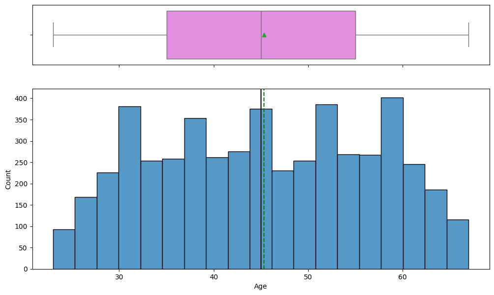

```python
histogram_boxplot(data, "Age")
```

- The `Age` distribution approximately symmetric but not perfectly normally distributed
- The mean Age is around 45.
- There is no outlier present.

#### Observations on Experience

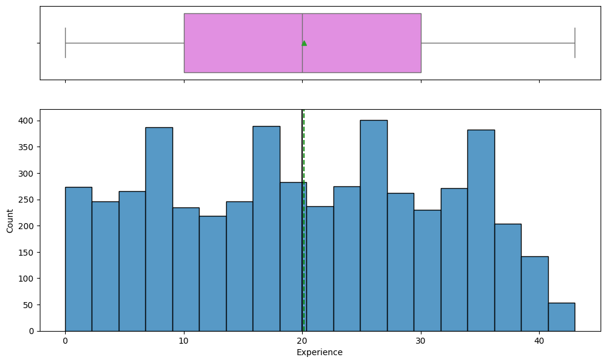

```python
histogram_boxplot(data,"Experience")
```

- The experience levels are fairly evenly distributed, with a balanced representation from 0 to 40+ years.
- The median experience is around 20 years, suggesting that the customer base is primarily composed of mid-career professionals.
- There is no outlier present.

#### Observations on Income

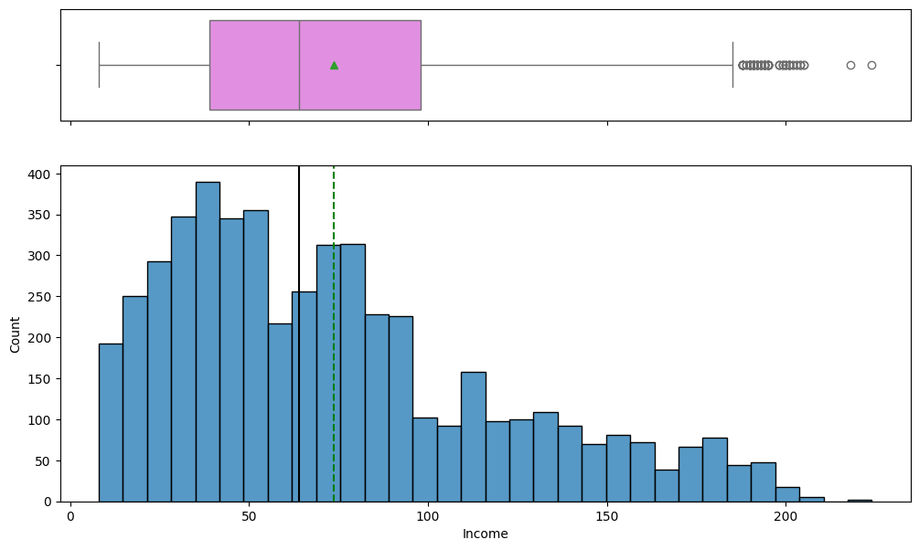

```python
histogram_boxplot(data,"Income")
```

- Most customers have an income below $100,000, which indicating a right skewed distribution.
- There are a few outliers with incomes exceeding $180,000, representing a small group with significantly higher earning capacity.

#### Observations on CCAvg

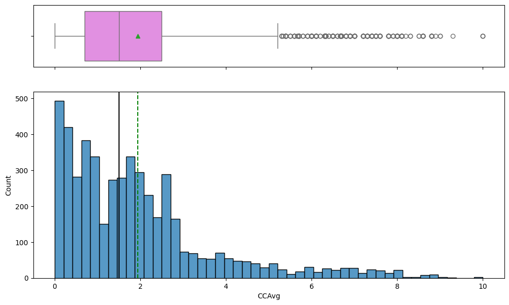

```python
histogram_boxplot(data,"CCAvg")
```

#### Observations on Mortgage

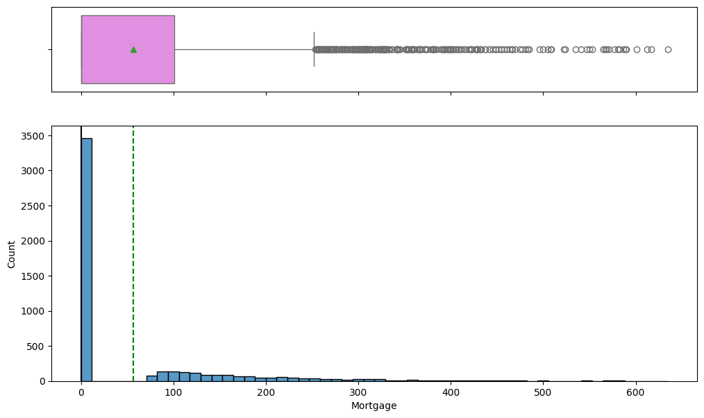

```python
histogram_boxplot(data,"Mortgage")
```

- A large portion of customers have no mortgage, indicating they either own their homes outright or do not hold property assets with mortgage liabilities.
- There is a right-skew in the distribution with more outliers, suggesting that only a small subset of customers having mortgage values.

#### Observation on ZIPCode

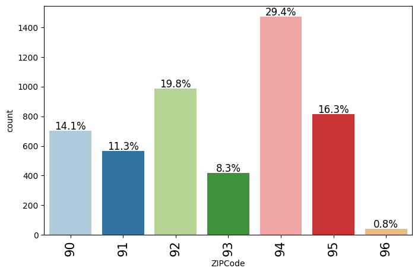

```python
labeled_barplot(data, "ZIPCode", perc=True)
```

- This distribution suggests that ZIP Code 94(29.4%) is the bank’s largest customer area, while ZIP Code 96(0.8%) has minimal representation.

#### Observation on Family

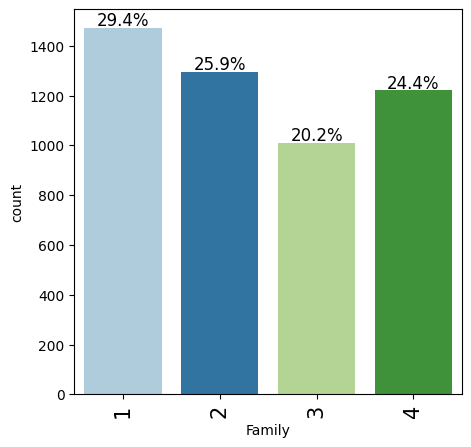

```python
labeled_barplot(data, "Family", perc=True)
```

- The customer distribution by family size shows that  
  **29.4%** have a family size of **1**,  
  **25.9%** have a family size of **2**,  
  **20.2%** have a family size of **3**, and  
  **24.4%** have a family size of **4**,  
  indicating a fairly even spread across different family sizes.

#### Observation on Education

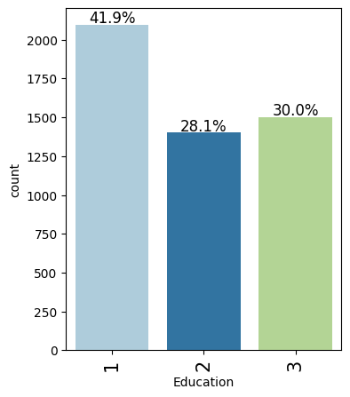

```python
labeled_barplot(data, "Education", perc=True)
```

- The majority **41.9%** of customers have an undergraduate education, representing a significant portion of the bank's customer base.
- A substantial **28.1%** of customers hold a graduate-level education.
- **30%** of Customers with advanced or professional education.

#### Observation on Personal Loan

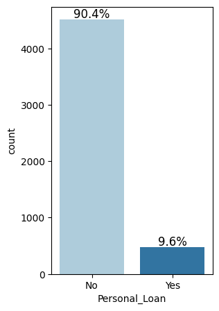

```python
labeled_barplot1(data, "Personal_Loan", perc=True)
```

- A large majority (90.4%) of customers did not accept the personal loan offer, indicating possible hesitation towards borrowing or satisfaction with their current financial situation.
- Only 9.6% of customers accepted the personal loan, highlighting a small group that may have financial needs.

#### Observations on Securities_Account

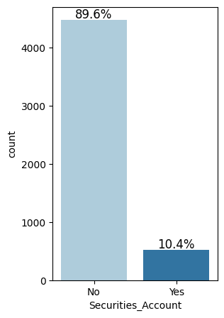

```python
labeled_barplot1(data, "Securities_Account", perc=True)
```

- The majority of customers (89.6%) do not hold a securities account with the bank
- A small segment (10.4%) of customers have a securities account

#### Observations on CD_Account

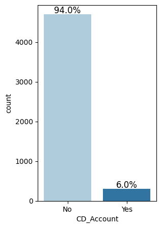

```python
labeled_barplot1(data, "CD_Account", perc=True)
```

- The majority of customers (94%) do not hold a Certificate of Deposit (CD) account with the bank
- Only 6% of customers have a CD account

#### Observations on Online

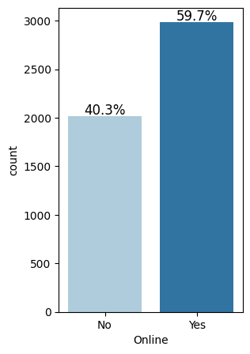

```python
labeled_barplot1(data, "Online", perc=True)
```

- The 40.3% of customers who do not use online banking may prefer traditional banking methods or have limited access to digital services.
- The 59.7% of customers using online banking are more digitally engaged and likely responsive to online offers.

#### Observations on Credit Card

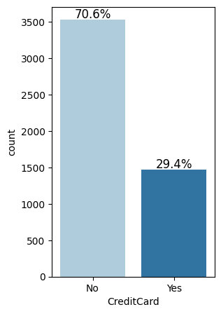

```python
labeled_barplot1(data, "CreditCard", perc=True)
```

- Approximately 70.6% of customers do not use credit cards from other banks, which might be advantageous for targeting personal loan offers.
- Only 29.4% of customers using other bank Credit card.

### Numerical vs Numerical

#### Observations on Income vs CCAverage

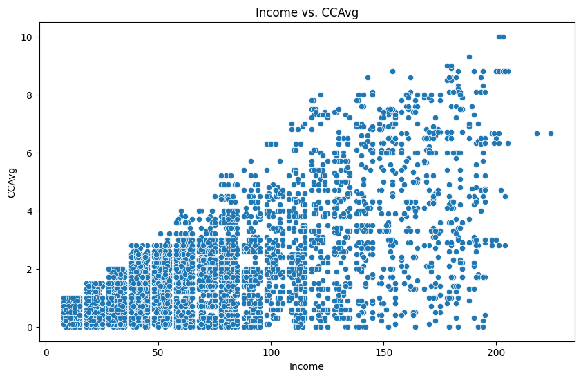

```python
# Scatterplot Income vs CCAvg

plt.figure(figsize=(10, 6))
sns.scatterplot(data=data, x='Income', y='CCAvg')
plt.title('Income vs. CCAvg')
plt.xlabel('Income')
plt.ylabel('CCAvg')
plt.show()
```

- The scatterplot shows a positive correlation between income and average monthly credit card spending (CCAvg), indicating that as income increases, customers tend to spend more on their credit cards.
- There is a higher density of customers with incomes up to $100K, suggesting that most customers fall within this income range.

#### Observations on Income vs Experience

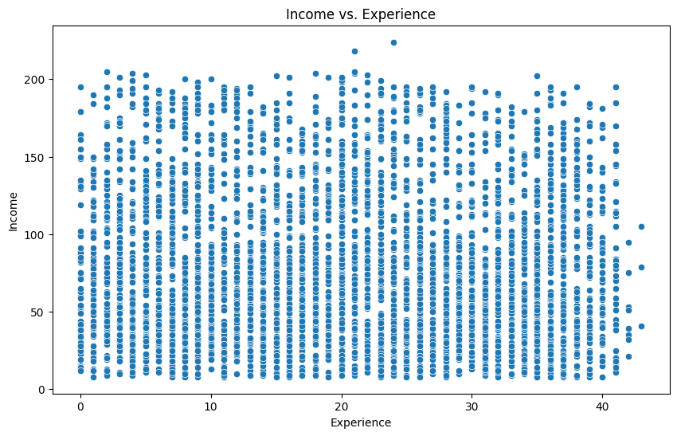

```python
# Scatterplot Income vs Experience
plt.figure(figsize=(10, 6))
sns.scatterplot(data=data, x='Experience', y='Income')
plt.title('Income vs. Experience')
plt.xlabel('Experience')
plt.ylabel('Income')
plt.show()
```

#### Observations on Income vs Age

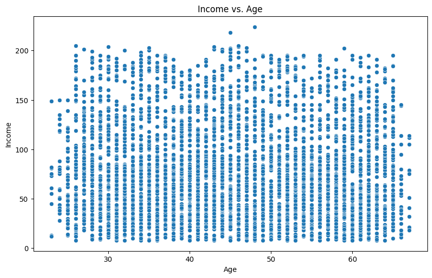

```python
# Generate a scatterplot for Income vs Age

plt.figure(figsize=(10, 6))
sns.scatterplot(data=data, x='Age', y='Income')
plt.title('Income vs. Age')
plt.xlabel('Age')
plt.ylabel('Income')
plt.show()
```

- The scatter plot of "Income vs. Age" shows that income levels are widely distributed across all age groups

### Numerical vs. Categorical

### Observations on Income by Educational Level

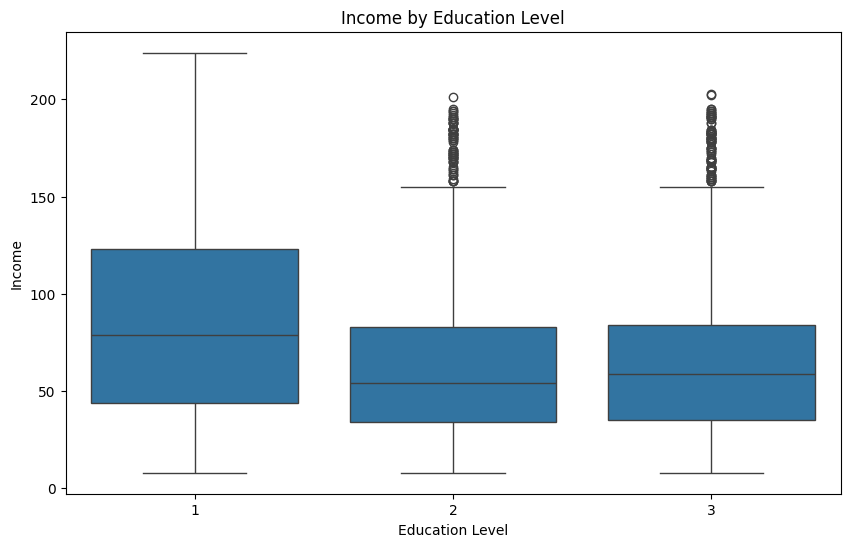

```python
# Create boxplot for Income by Education level

plt.figure(figsize=(10, 6))
sns.boxplot(x='Education', y='Income', data=data)
plt.title('Income by Education Level')
plt.xlabel('Education Level')
plt.ylabel('Income')
plt.show()
```

### Observations on CCAvg by Personal Loan status

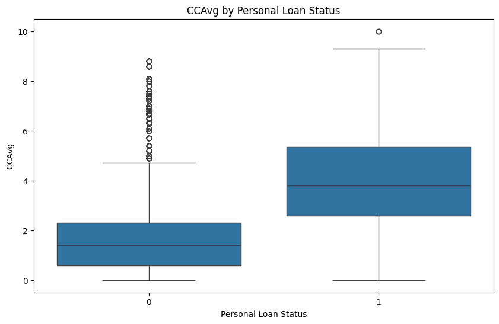

```python
# Create boxplot for CCAvg by Personal Loan status

plt.figure(figsize=(12, 6))
sns.boxplot(x='Personal_Loan', y='CCAvg', data=data)
plt.title('CCAvg by Personal Loan Status')
plt.xlabel('Personal Loan Status')
plt.ylabel('CCAvg')
plt.show()
```

- Customers who accepted personal loans (status = 1) generally have higher average credit card spending than those who did not. This may suggest that higher spenders are more likely to take up personal loans, making them a potential target segment for future campaigns.
- Outliers are more on those not accept personal loan compared to those who accepted personal loan.

### Observations on Age by Security Account

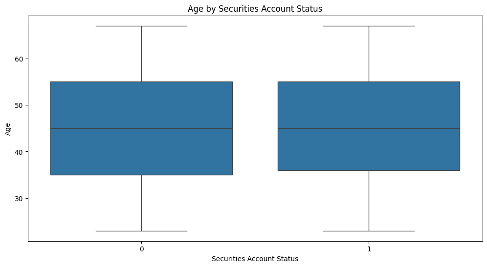

```python
# Create boxplot for Age  by Securities_Account

plt.figure(figsize=(12, 6))
sns.boxplot(x='Securities_Account', y='Age', data=data)
plt.title('Age by Securities Account Status')
plt.xlabel('Securities Account Status')
plt.ylabel('Age')
plt.show()
```

- Both categories of Securities_Account have a similar age range and median, indicating that age alone does not strongly influence the likelihood of having a securities account.
- The spread and interquartile range (IQR) are also quite similar for both groups, suggesting that customers of various ages are equally likely to hold or not hold a securities account.
- The median age for customers with/without a securities account is around 45, with most ages ranging from approximately 30 to 60.

```python
def stacked_barplot1(data, predictor, target):
    """
    Print the category counts and plot a stacked bar chart with titles and labels

    data: dataframe
    predictor: independent variable
    target: target variable
    """
    count = data[predictor].nunique()
    sorter = data[target].value_counts().index[-1]
    tab1 = pd.crosstab(data[predictor], data[target], margins=True).sort_values(
        by=sorter, ascending=False
    )
    print(tab1)
    print("-" * 85)

    # Prepare the data for plotting
    tab = pd.crosstab(data[predictor], data[target], normalize="index").sort_values(
        by=sorter, ascending=False
    )

    # Plot the stacked bar chart
    ax = tab.plot(kind="bar", stacked=True, figsize=(count + 5, 5), color=['#1f77b4', '#ff7f0e'])

    # Add titles and labels
    ax.set_title(f'Distribution of {target} by {predictor}', fontsize=14)
    ax.set_xlabel(predictor, fontsize=12)
    ax.set_ylabel(f'Proportion of {target}', fontsize=12)

    # Format the legend
    plt.legend(title=target, loc="upper left", bbox_to_anchor=(1, 1), frameon=False)

    # Optional: Display percentages on each bar segment (for better readability)
    for i in range(len(tab)):
        for j in range(len(tab.columns)):
            plt.text(
                i,
                tab.iloc[i, :j+1].sum() - tab.iloc[i, j] / 2,
                f"{tab.iloc[i, j]:.1%}",
                ha="center", va="center", color="white", fontsize=10
            )

    plt.tight_layout()  # Adjust layout for readability
    plt.show()
```

```python
### function to plot distributions wrt target


def distribution_plot_wrt_target(data, predictor, target):

    fig, axs = plt.subplots(2, 2, figsize=(12, 10))

    target_uniq = data[target].unique()

    axs[0, 0].set_title("Distribution of target for target=" + str(target_uniq[0]))
    sns.histplot(
        data=data[data[target] == target_uniq[0]],
        x=predictor,
        kde=True,
        ax=axs[0, 0],
        color="teal",
        stat="density",
    )

    axs[0, 1].set_title("Distribution of target for target=" + str(target_uniq[1]))
    sns.histplot(
        data=data[data[target] == target_uniq[1]],
        x=predictor,
        kde=True,
        ax=axs[0, 1],
        color="orange",
        stat="density",
    )

    axs[1, 0].set_title("Boxplot w.r.t target")
    sns.boxplot(data=data, x=target, y=predictor, ax=axs[1, 0], palette="gist_rainbow")

    axs[1, 1].set_title("Boxplot (without outliers) w.r.t target")
    sns.boxplot(
        data=data,
        x=target,
        y=predictor,
        ax=axs[1, 1],
        showfliers=False,
        palette="gist_rainbow",
    )

    plt.tight_layout()
    plt.show()
```

### Categorical vs. Categorical

### Observations on Education vs Personal_Loan

```
Personal_Loan     0    1   All
Education
All            4520  480  5000
3              1296  205  1501
2              1221  182  1403
1              2003   93  2096
-------------------------------------------------------------------------------------
```

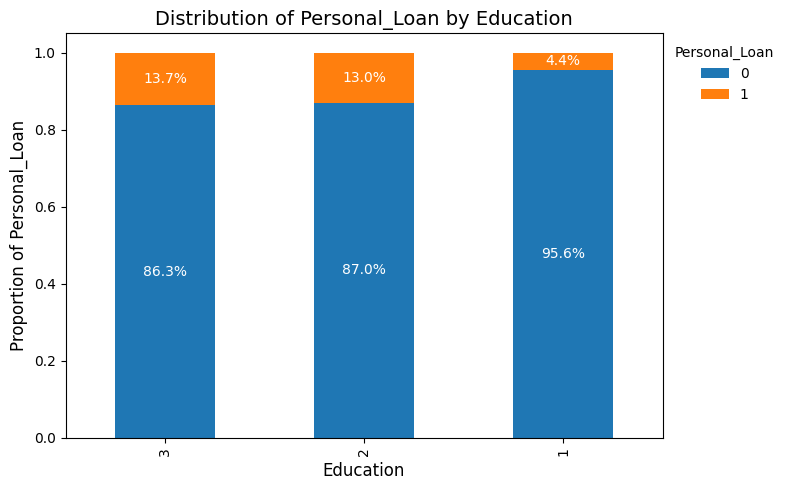

```python
stacked_barplot1(data, "Education", "Personal_Loan")
```

- **Education Level 3:** Customers with the highest education level (3) have the highest rate of personal loan acceptance, suggesting they may be more open to financial products.
- **Education Level 2:** Intermediate education level (2) shows a moderate acceptance rate, with 182 out of 1403 accepting personal loans.
- **Education Level 1:** Customers with the lowest education level (1) have the lowest acceptance rate.
- **Overall Acceptance:** Personal loan acceptance is relatively low across all groups, with only 480 out of 5000 customers accepting, suggesting that more targeted campaigns may be needed to increase conversion.

### Observations on Online vs CreditCard

```
CreditCard     0     1   All
Online
All         3530  1470  5000
1           2102   882  2984
0           1428   588  2016
-------------------------------------------------------------------------------------
```

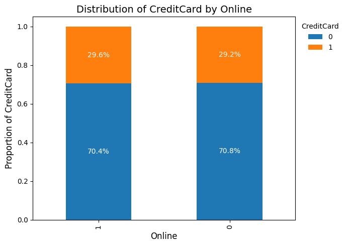

```python
stacked_barplot1(data, "Online", "CreditCard")
```

- Customers who use online banking (70.4%) and those who do not (70.8%) are almost equally likely not to have a credit card, indicating that online banking usage has minimal influence on credit card ownership among these groups.

### Observations on Security_Account vs. CD_Account

```
CD_Account             0    1   All
Securities_Account
All                 4698  302  5000
0                   4323  155  4478
1                    375  147   522
-------------------------------------------------------------------------------------
```

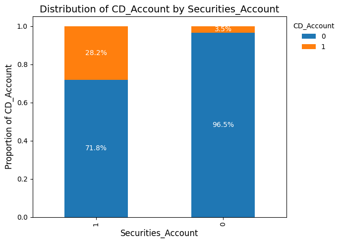

```python
stacked_barplot1(data, "Securities_Account", "CD_Account")
```

- The majority of customers without a securities account (**96.5%**) do not have a CD account, suggesting that customers who don't engage in investment-related products are also less likely to hold savings certificates like CDs.
- Customers with a securities account are more likely to also have a CD account (**28.2%**) compared to those without a securities account (**3.5%**).

#### Let's check Customer's intersert on Personal Loan with respect to Age, Income, Experience and CCAverage

#### Personal Loan vs. Age

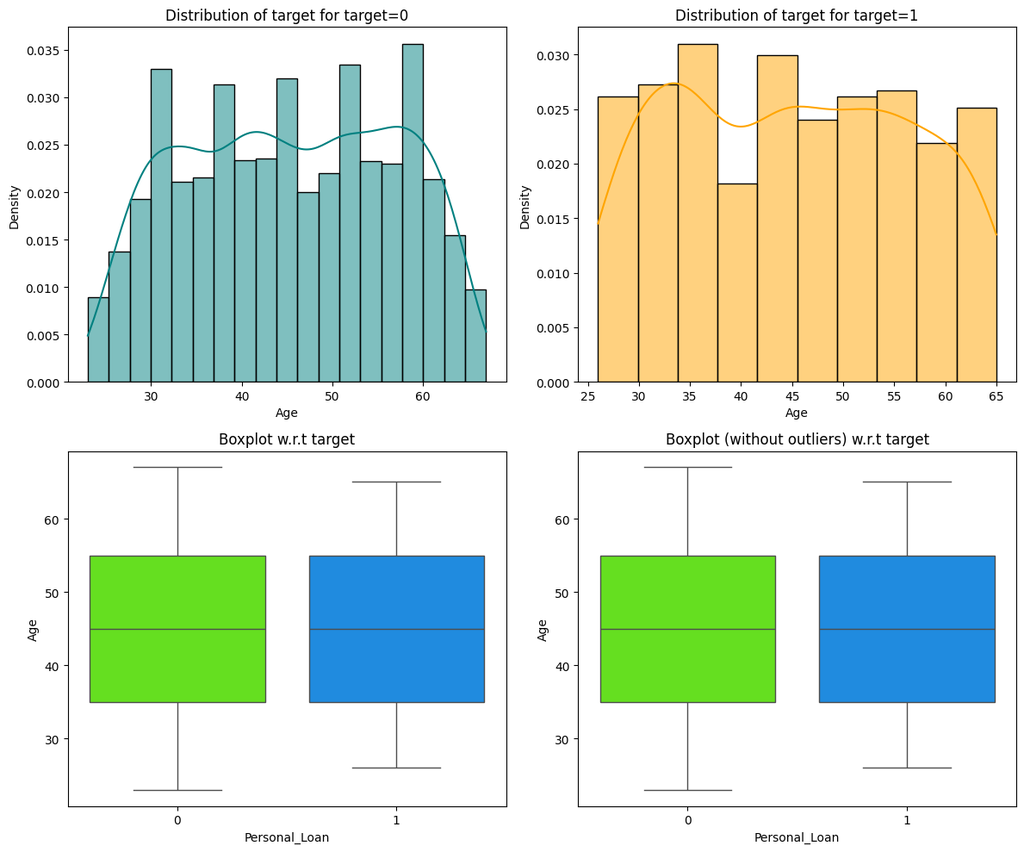

```python
distribution_plot_wrt_target(data, "Age", "Personal_Loan")
```

- The age distributions for both groups (those who accepted and did not accept the personal loan) are fairly similar, with a slightly higher density of loan acceptance among customers aged 35-55.
- The boxplots indicate that age alone does not show a significant difference between those who accepted and those who declined the loan, suggesting that age may not be a strong predictor for loan acceptance on its own.
- There are no outliers in age for either group.

#### Personal Loan vs Experience

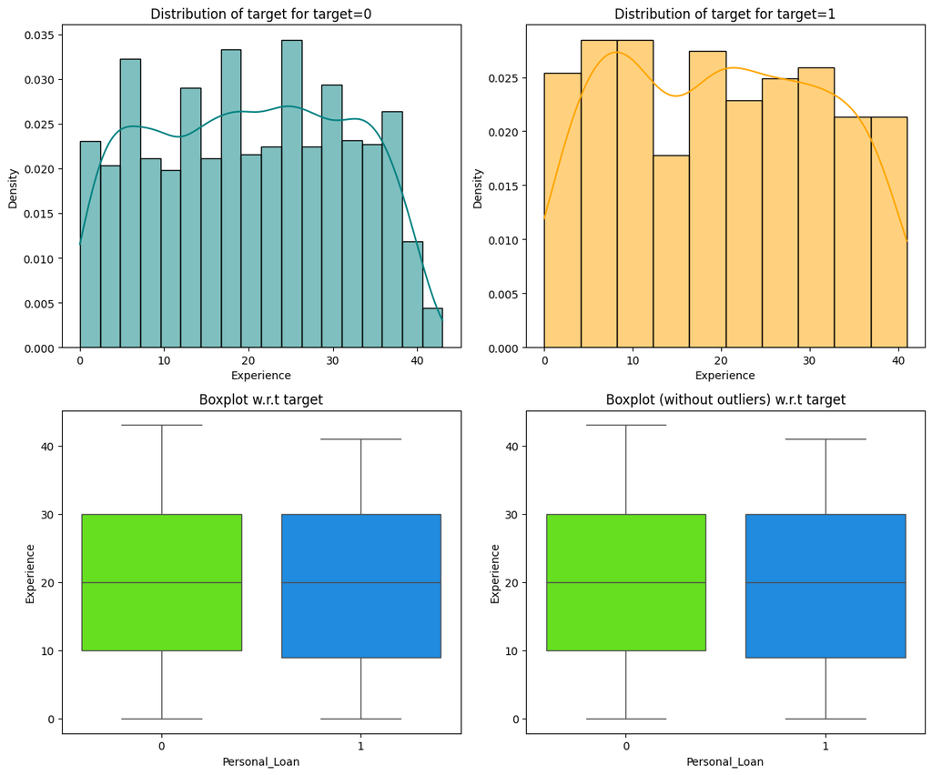

```python
distribution_plot_wrt_target(data, "Experience", "Personal_Loan")
```

- The experience distributions for both groups (those who accepted and did not accept the personal loan) are similar, with a slightly higher density of loan acceptance among customers with 10-30 years of experience.
- The boxplots show no significant difference in experience between the two groups, indicating that experience alone may not be a strong predictor for loan acceptance, and there are no notable outliers affecting the analysis.

#### Personal Loan vs Income

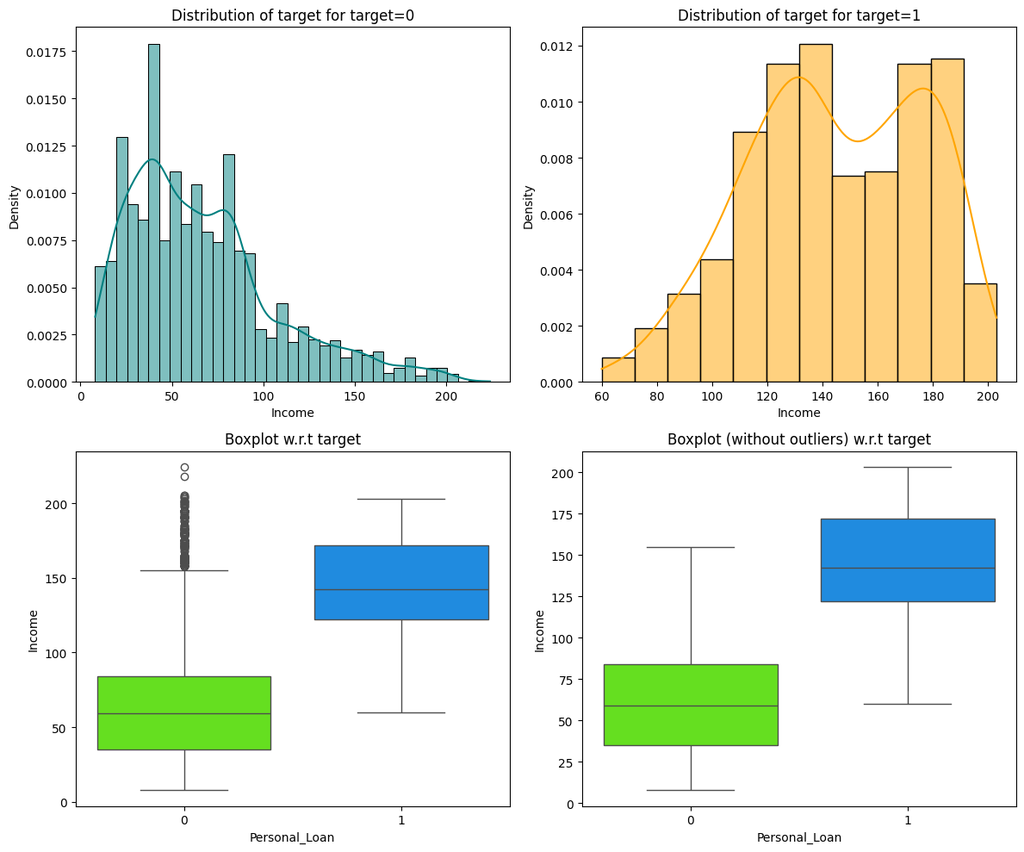

```python
distribution_plot_wrt_target(data, "Income", "Personal_Loan")
```

- The income distributions show a clear distinction between those who accepted and those who did not accept the personal loan.
- Customers who accepted the loan generally have higher incomes, with most falling in the 100K to 200K range, while those who did not accept have lower incomes concentrated below 100K.
- The boxplots reinforce this insight, showing a higher median income for loan acceptors and significant income outliers among non-acceptors, suggesting that higher-income customers are more likely to accept personal loan offers.

#### Personal Loan vs CCAvg

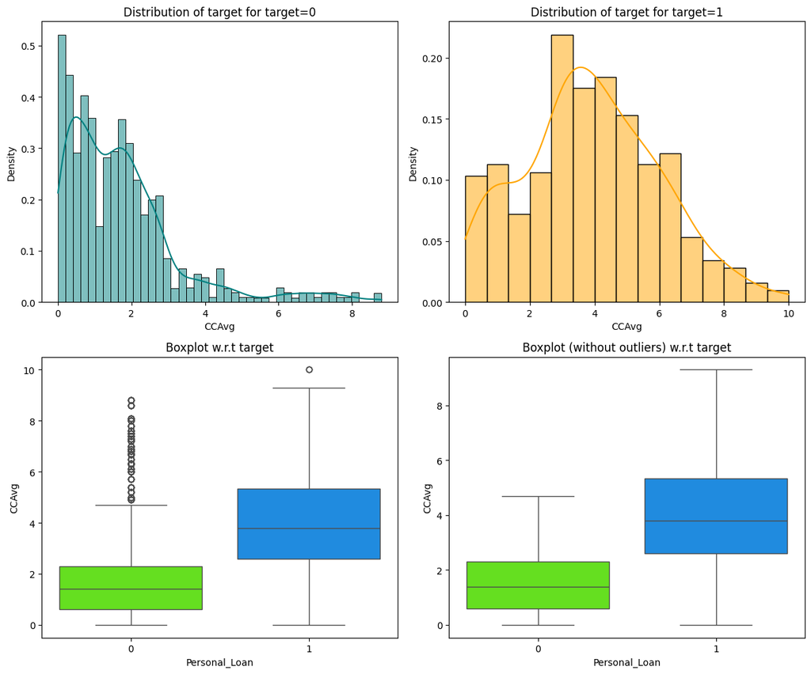

```python
distribution_plot_wrt_target(data, "CCAvg", "Personal_Loan")
```

- The analysis of "CCAvg" (average credit card spending) reveals a clear distinction between customers who accepted and those who declined personal loans.
- The distribution for non-loan customers is highly right-skewed, with most values concentrated below 3K, while loan acceptors exhibit a more evenly distributed spending pattern, primarily ranging between 3K and 6K.
- The boxplots further emphasize this difference, showing a higher median CCAvg for loan acceptors and more outliers among those who declined loans. This suggests that higher credit card spending is a significant indicator of loan acceptance, making it an important attribute for targeting potential loan buyers.

#### Correlation check using Heatmap

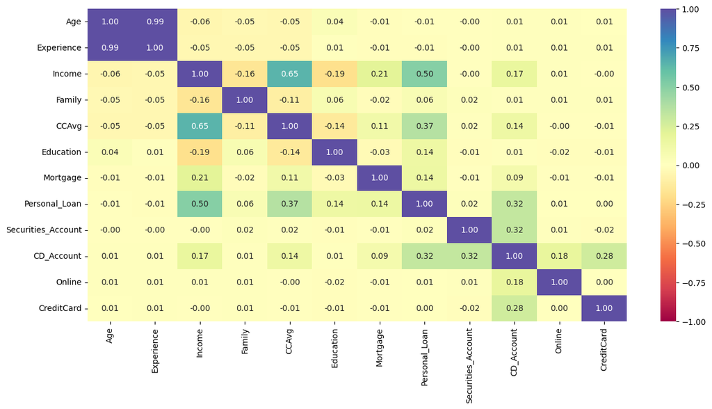

```python
plt.figure(figsize=(15, 7))
sns.heatmap(data.corr(numeric_only=True), annot=True, vmin=-1, vmax=1, fmt=".2f", cmap="Spectral") # Complete the code to get the heatmap of the data
plt.show()
```

#### Observations:

- Age and experience are highly correlated. We can remove one column
- CCAvg and Income also has some sort of +ve correlation
- Income, CCAvg and CD Account have some +ve correlations with Personal loan
- Income influences CCAvg, Personal Loan, CD Account and Mortgage.

### EDA Conclusions to address the below Questions

**Questions**:

Q1) What is the distribution of mortgage attribute? Are there any noticeable patterns or outliers in the distribution?

- **Answer:** The distribution of the "Mortgage" attribute is generally right-skewed, with most customers having a mortgage value close to zero. There are outliers with high mortgage values, indicating that only a small number of customers have significant mortgage amounts.

Q2) How many customers have credit cards?

- **Answer:** From the analysis, approximately 1,470 customers out of 5,000 have credit cards

Q3) What are the attributes that have a strong correlation with the target attribute (personal loan)?

Q4) How does a customer's interest in purchasing a loan vary with their age?

- **Answer:** The age distribution shows similar loan acceptance across groups, with a slightly higher interest among customers aged 30-55, suggesting middle-aged customers may be more likely to accept loans.

Q5) How does a customer's interest in purchasing a loan vary with their education?

- **Answer:** Customers with higher education levels (especially Level 3, Advanced/Professional) show a greater likelihood of accepting personal loans, suggesting that education level positively influences interest in loan offers.

## Data Preprocessing

- Missing value treatment
- Feature engineering (if needed)
- Outlier detection and treatment (if needed)
- Preparing data for modeling
- Any other preprocessing steps (if needed)

**Conclusion** : From the EDA Analysis No missing values, Feature Engineering done for ZipCode, Outliers detections and insights were addressed in the EDA part. Negative experience changed to positive experience(as preprocessing).

### Data Preparation for Modeling

```python
# dropping Experience as it is perfectly correlated with Age
X = data.drop(["Personal_Loan", "Experience"], axis=1)
Y = data["Personal_Loan"]

# Perform one-hot encoding on "ZIPCode" and "Education" columns, dropping the first category to avoid multicollinearity
X = pd.get_dummies(X, columns=["ZIPCode", "Education"], drop_first=True)
X = X.astype(float)

# Splitting data in train and test sets
X_train, X_test, y_train, y_test = train_test_split(
    X, Y, test_size=0.30, random_state=1
)
```

```python
# Printing the Training and Testing data shapes and proportion
print("Shape of Training set : ", X_train.shape)
print("Shape of test set : ", X_test.shape)
print("Percentage of classes in training set:")
print(y_train.value_counts(normalize=True))
print("Percentage of classes in test set:")
print(y_test.value_counts(normalize=True))
```

```
Shape of Training set :  (3500, 17)
Shape of test set :  (1500, 17)
Percentage of classes in training set:
Personal_Loan
0    0.905429
1    0.094571
Name: proportion, dtype: float64
Percentage of classes in test set:
Personal_Loan
0    0.900667
1    0.099333
Name: proportion, dtype: float64
```

## Model Building

### Model Evaluation Criterion

- Before building a model, it's essential to establish clear evaluation criteria to ensure that the model's performance aligns with the business goals of the bank.

**Types of Wrong Predictions**

- **False Positives (Type I Error):** This occurs when the model predicts a customer will accept a personal loan, but they do not. This can lead to wasted marketing efforts and resources as well as possible annoyance from customers who are not interested in the loan.
- **False Negatives (Type II Error):** This occurs when the model predicts a customer will not accept a personal loan, but they actually would have. This means a missed opportunity for the bank, as potential revenue from interest on loans is lost.

**Which case is more important?**

- **Missing a potential loan buyer (False Negative):** If we predict that a customer will not buy a loan but, in reality, the customer would have, we miss an opportunity to generate revenue from loan interest and fail to convert a liability customer into a valuable asset customer. This missed conversion could significantly impact the bank's goal of growing its loan customer base.
- **Marketing to an uninterested customer (False Positive):** If we predict that a customer will buy a loan but, in reality, the customer does not, the bank may waste marketing resources on a customer unlikely to convert. While this incurs some cost, it is generally lower than the cost of lost revenue from missing an actual loan buyer.
- In this scenario, the cost of missed opportunities (False Negatives) outweighs the cost of unnecessary marketing (False Positives), making it crucial to **prioritize recall** to capture as many true loan buyers as possible.

```python
# defining a function to compute different metrics to check performance of a classification model built using sklearn
def model_performance_classification_sklearn(model, predictors, target):
    """
    Function to compute different metrics to check classification model performance

    model: classifier
    predictors: independent variables
    target: dependent variable
    """

    # predicting using the independent variables
    pred = model.predict(predictors)

    acc = accuracy_score(target, pred)  # to compute Accuracy
    recall = recall_score(target, pred)  # to compute Recall
    precision = precision_score(target, pred)  # to compute Precision
    f1 = f1_score(target, pred)  # to compute F1-score

    # creating a dataframe of metrics
    df_perf = pd.DataFrame(
        {"Accuracy": acc, "Recall": recall, "Precision": precision, "F1": f1,},
        index=[0],
    )

    return df_perf
```

```python
def confusion_matrix_sklearn(model, predictors, target):
    """
    To plot the confusion_matrix with percentages

    model: classifier
    predictors: independent variables
    target: dependent variable
    """
    y_pred = model.predict(predictors)
    cm = confusion_matrix(target, y_pred)
    labels = np.asarray(
        [
            ["{0:0.0f}".format(item) + "\n{0:.2%}".format(item / cm.flatten().sum())]
            for item in cm.flatten()
        ]
    ).reshape(2, 2)

    plt.figure(figsize=(6, 4))
    sns.heatmap(cm, annot=labels, fmt="")
    plt.ylabel("True label")
    plt.xlabel("Predicted label")
```

### Decision Tree (Default)

```python
# creating an instance of the decision tree model
model = DecisionTreeClassifier(criterion="gini", random_state=1)
# fitting the model to the training data
model.fit(X_train, y_train)
```

```
DecisionTreeClassifier(random_state=1)
```

#### Checking model performance on training data

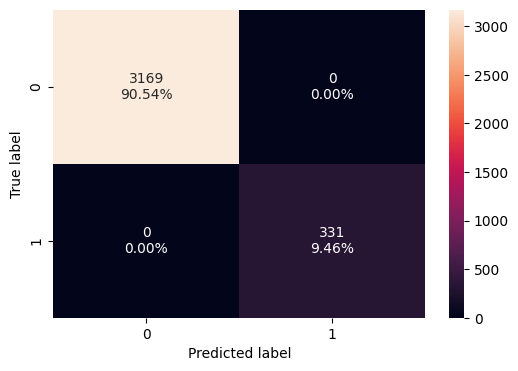

```python
#Show the Confusion Matrix on the Training data
confusion_matrix_sklearn(model, X_train, y_train)
```

```python
# Performance measures on Training data
decision_tree_perf_train = model_performance_classification_sklearn(
    model, X_train, y_train
)
decision_tree_perf_train
```

|  | Accuracy | Recall | Precision | F1 |
| --- | --- | --- | --- | --- |
| 0 | 1.0 | 1.0 | 1.0 | 1.0 |

- Model is able to perfectly classify all the data points on the training set.
- 0 errors on the training set, each sample has been classified correctly.
- As we know a decision tree will continue to grow and classify each data point correctly if no restrictions are applied as the trees will learn all the patterns in the training set.
- This generally leads to overfitting of the model as Decision Tree will perform well on the training set but will fail to replicate the performance on the test set.

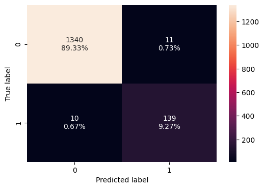

```python
#Show the Confusion Matrix on the Test data
confusion_matrix_sklearn(model, X_test, y_test)
```

```python
# Retrieve the performance measures on test data

decision_tree_perf_test = model_performance_classification_sklearn(
    model, X_test, y_test
)
decision_tree_perf_test
```

|  | Accuracy | Recall | Precision | F1 |
| --- | --- | --- | --- | --- |
| 0 | 0.986 | 0.932886 | 0.926667 | 0.929766 |

**Observations from Test data**

- The decision tree model is performing well across these metrics, suggesting it has been trained effectively to balance precision and recall.
- The high recall(**93.3%**) is beneficial for identifying almost all potential loan customers, ensuring fewer missed opportunities.
- The high precision(**92.6%**) also indicates targeted marketing efforts, with fewer misallocated resources.
- Given that test data results show varied metrics rather than default values, it indicates that the model is intelligently making decisions based on patterns and not defaulting to classifying all or most instances into a single class.

**Recommendations**

- While the metrics appear strong on test data, it's always important to consider any class imbalance and the business context to ensure that the decision tree truly meets the needs of the bank’s campaign goals.
- Further evaluation against business objectives and possibly incorporating additional model improvement techniques, such as pruning, might help further refine the model.

#### Visualizing the Decision Tree

```python
#Displaying the Featuresc col
feature_names = list(X_train.columns)
print(feature_names)
```

```
['Age', 'Income', 'Family', 'CCAvg', 'Mortgage', 'Securities_Account', 'CD_Account', 'Online', 'CreditCard', 'ZIPCode_91', 'ZIPCode_92', 'ZIPCode_93', 'ZIPCode_94', 'ZIPCode_95', 'ZIPCode_96', 'Education_2', 'Education_3']
```

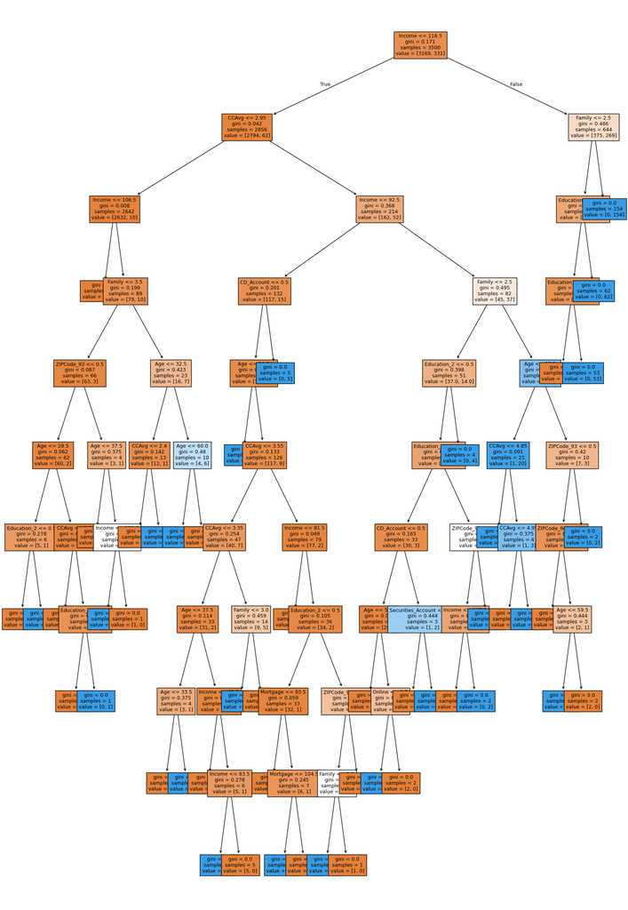

```python
#Display the Default Decision Binary Tree structure
plt.figure(figsize=(20, 30))
out = tree.plot_tree(
    model,
    feature_names=feature_names,
    filled=True,
    fontsize=9,
    node_ids=False,
    class_names=None,
)
# below code will add arrows to the decision tree split if they are missing
for o in out:
    arrow = o.arrow_patch
    if arrow is not None:
        arrow.set_edgecolor("black")
        arrow.set_linewidth(1)
plt.show()
```

- We can observe that this is a very complex tree.

```python
# Text report showing the rules of a decision tree -

print(tree.export_text(model, feature_names=feature_names, show_weights=True))
```

```
|--- Income <= 116.50
|   |--- CCAvg <= 2.95
|   |   |--- Income <= 106.50
|   |   |   |--- weights: [2553.00, 0.00] class: 0
|   |   |--- Income >  106.50
|   |   |   |--- Family <= 3.50
|   |   |   |   |--- ZIPCode_93 <= 0.50
|   |   |   |   |   |--- Age <= 28.50
|   |   |   |   |   |   |--- Education_2 <= 0.50
|   |   |   |   |   |   |   |--- weights: [5.00, 0.00] class: 0
|   |   |   |   |   |   |--- Education_2 >  0.50
|   |   |   |   |   |   |   |--- weights: [0.00, 1.00] class: 1
|   |   |   |   |   |--- Age >  28.50
|   |   |   |   |   |   |--- CCAvg <= 2.20
|   |   |   |   |   |   |   |--- weights: [48.00, 0.00] class: 0
|   |   |   |   |   |   |--- CCAvg >  2.20
|   |   |   |   |   |   |   |--- Education_3 <= 0.50
|   |   |   |   |   |   |   |   |--- weights: [7.00, 0.00] class: 0
|   |   |   |   |   |   |   |--- Education_3 >  0.50
|   |   |   |   |   |   |   |   |--- weights: [0.00, 1.00] class: 1
|   |   |   |   |--- ZIPCode_93 >  0.50
|   |   |   |   |   |--- Age <= 37.50
|   |   |   |   |   |   |--- weights: [2.00, 0.00] class: 0
|   |   |   |   |   |--- Age >  37.50
|   |   |   |   |   |   |--- Income <= 112.00
|   |   |   |   |   |   |   |--- weights: [0.00, 1.00] class: 1
|   |   |   |   |   |   |--- Income >  112.00
|   |   |   |   |   |   |   |--- weights: [1.00, 0.00] class: 0
|   |   |   |--- Family >  3.50
|   |   |   |   |--- Age <= 32.50
|   |   |   |   |   |--- CCAvg <= 2.40
|   |   |   |   |   |   |--- weights: [12.00, 0.00] class: 0
|   |   |   |   |   |--- CCAvg >  2.40
|   |   |   |   |   |   |--- weights: [0.00, 1.00] class: 1
|   |   |   |   |--- Age >  32.50
|   |   |   |   |   |--- Age <= 60.00
|   |   |   |   |   |   |--- weights: [0.00, 6.00] class: 1
|   |   |   |   |   |--- Age >  60.00
|   |   |   |   |   |   |--- weights: [4.00, 0.00] class: 0
|   |--- CCAvg >  2.95
```

[output cut: 90 more lines]

```
|   |   |   |   |   |   |   |--- Age >  59.50
|   |   |   |   |   |   |   |   |--- weights: [2.00, 0.00] class: 0
|   |   |   |   |   |--- ZIPCode_93 >  0.50
|   |   |   |   |   |   |--- weights: [0.00, 2.00] class: 1
|--- Income >  116.50
|   |--- Family <= 2.50
|   |   |--- Education_3 <= 0.50
|   |   |   |--- Education_2 <= 0.50
|   |   |   |   |--- weights: [375.00, 0.00] class: 0
|   |   |   |--- Education_2 >  0.50
|   |   |   |   |--- weights: [0.00, 53.00] class: 1
|   |   |--- Education_3 >  0.50
|   |   |   |--- weights: [0.00, 62.00] class: 1
|   |--- Family >  2.50
|   |   |--- weights: [0.00, 154.00] class: 1
```

```python
# importance of features in the tree building ( The importance of a feature is computed as the
# (normalized) total reduction of the criterion brought by that feature. It is also known as the Gini importance )

print(
    pd.DataFrame(
        model.feature_importances_, columns=["Imp"], index=X_train.columns
    ).sort_values(by="Imp", ascending=False)
)
```

```
                         Imp
Income              0.308098
Family              0.259255
Education_2         0.166192
Education_3         0.147127
CCAvg               0.048798
Age                 0.033150
CD_Account          0.017273
ZIPCode_94          0.007183
ZIPCode_93          0.004682
Mortgage            0.003236
Online              0.002224
Securities_Account  0.002224
ZIPCode_91          0.000556
ZIPCode_92          0.000000
ZIPCode_95          0.000000
ZIPCode_96          0.000000
CreditCard          0.000000
```

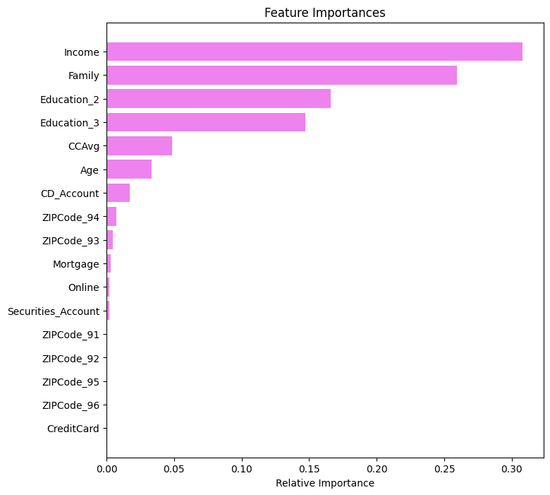

```python
# plotting the importance feasures
importances = model.feature_importances_
indices = np.argsort(importances)

plt.figure(figsize=(8, 8))
plt.title("Feature Importances")
plt.barh(range(len(indices)), importances[indices], color="violet", align="center")
plt.yticks(range(len(indices)), [feature_names[i] for i in indices])
plt.xlabel("Relative Importance")
plt.show()
```

**Observations**